# Task 3: Santa Barbara Urchins (SILVA)

German Silva

10/23/2021

# Overview

This code looks at sea urchin data from Santa Barbara, CA as an example and exercise in data wrangling and data visualization. Examples include: cleaning names, relative file paths, faceted graphs with captions, tables, and changing data class. Two sections exist: 1) Size distribution comparisons between two sea urchin species and 2) observations at different sites over time for Purple Urchins.

**Data Source**: Reed, D. 2020. SBC LTER: Reef: Long-term experiment: Kelp removal: Urchin size frequency distribution ver 20. Environmental Data Initiative. https://doi.org/10.6073/pasta/5a1e9ef03aa47bd2225c0bb98a02a63b.

```r
knitr::opts_chunk$set(echo = TRUE, warning = FALSE, message = FALSE)

# Attach packages
library(tidyverse)
library(here)
library(janitor)
library(kableExtra)
library(lubridate)
```

## Section 1: Size Comparisons between two species of sea urchins

### Data visualization of size distribution between two types of urchin

- Read in `urchin.csv`
- Clean names
- Separate names to obtain color column
- Group by color
- Create histogram of size distribution
  - reduce the number of bins

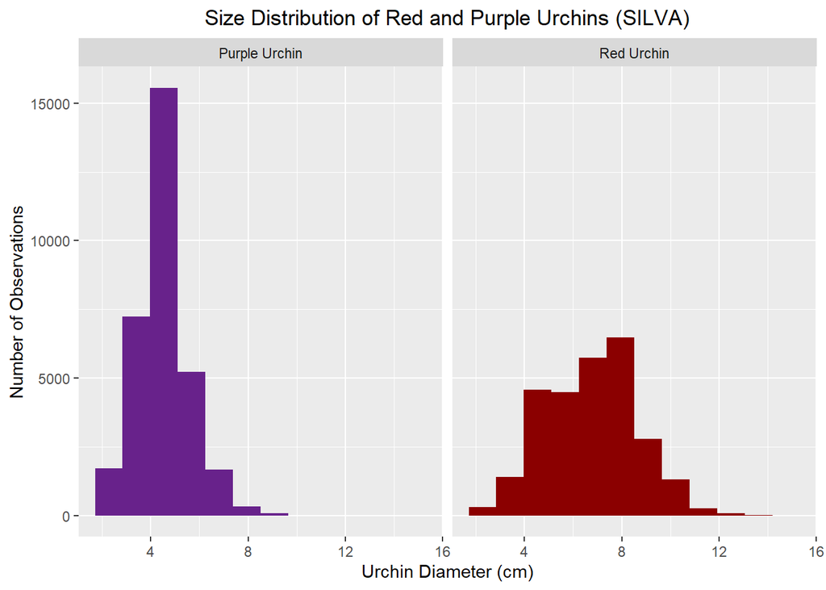

**Figure 1** Histograms showing the size distribution of two different species of urchin (red urchin and purple urchin). Purple urchin have smaller body sizes than red urchins and have less spread in data than their red counterparts. Table 1 shows numeric values to be used for further comparison

```r
# fig.cap = adds the caption to the knitted figure
urchins <- read_csv(here("data", "urchins.csv")) %>% # read in the data
  clean_names() %>% # clean names into lower_snakecase with clean_names()
  group_by(common_name) # create groups based on species common name

ggplot(urchins, aes(x = size, fill = common_name))+ # open the data and set the histogram variable and what to color by
  geom_histogram(bins = 12, position = "identity") + # set bins to 12 for a better visualization for this data, a personal choice of mine to always use "identity" as the position.
  facet_wrap(~ common_name) + # set what to facet the graphs by
  scale_color_manual(values = c("darkorchid4", "darkred")) + # set outline colors manually
  scale_fill_manual(values = c("darkorchid4", "darkred")) + # set fill colors for bars manually
  labs(x = "Urchin Diameter (cm)", # x-axis label
       y = "Number of Observations") + # y-axis label
  ggtitle("Size Distribution of Red and Purple Urchins (SILVA)") + # graph title
  theme(plot.title = element_text(hjust = 0.5), plot.caption = element_text(hjust = 0)) + # sets the center and left justifications for the title and caption.
  guides(fill= "none") # removes legend to reduce clutter and compression
```

### Descriptive Stats table

- Create a finalized stats table including:
  - mean
  - median
  - standard deviation
  - sample size

```r
urchins_stats <- urchins %>% # read in data
  group_by(common_name, scientific_name) %>% # group by common_name and scientific_name (i wanted both those details to remain in the summary table)
  summarize(mean_diameter_cm = round(mean(size), 2), # set the mean parameter as a rounded mean up to 2 decimal spots
            median_diameter_cm = median(size), # set the median parameter as a rounded median up to 2 decimal spots
            sd_cm = round(sd(size), 2), # set the sd parameter as a rounded sd up to 2 decimal spots
            sample_size = n()) # obtain observations

kable(urchins_stats, caption = "**Table 1** Urchin Size Statistics Table") # makes a table with a table caption
```

**Table 1** Urchin Size Statistics Table

| common_name | scientific_name | mean_diameter_cm | median_diameter_cm | sd_cm | sample_size |
| --- | --- | --- | --- | --- | --- |
| Purple Urchin | Strongylocentrotus purpuratus | 4.47 | 4.5 | 1.18 | 31805 |
| Red Urchin | Mesocentrotus franciscanus | 6.78 | 7.0 | 1.89 | 27408 |

**Takeaway Points**: Red Urchins (*Mesocentrotus franciscanus*) are larger in size compared to Purple Urchins (*Strongylocentrotus purpuratus*) as show by the difference in mean (6.78 cm vs. 4.47 cm) and median size (7 cm vs. 4.5 cm). Actual mean difference is 2.31 cm, or a % difference of 51.7 %. As shown by standard deviations (1.89 vs. 1.18), Red Urchins size distribution is more spread out compared to that of Purple Urchins.

## Section 2: Exploring purple urchin count by site and year

- Create a stored subset of the data in an object called `purple_urchins`
  - `filter()` for purple urchins
  - convert `date` to class “date”
  - create new column for `year` only
  - create new column for `site_full` that has full names of sites
- Write code that will create a table of total number of urchins per site by year
- Finalize a graph showing purple urchins recorded by site over time
  - Include caption
- Add text below graph explaining graph/what would be needed to explain changes in urchins
- Knit document

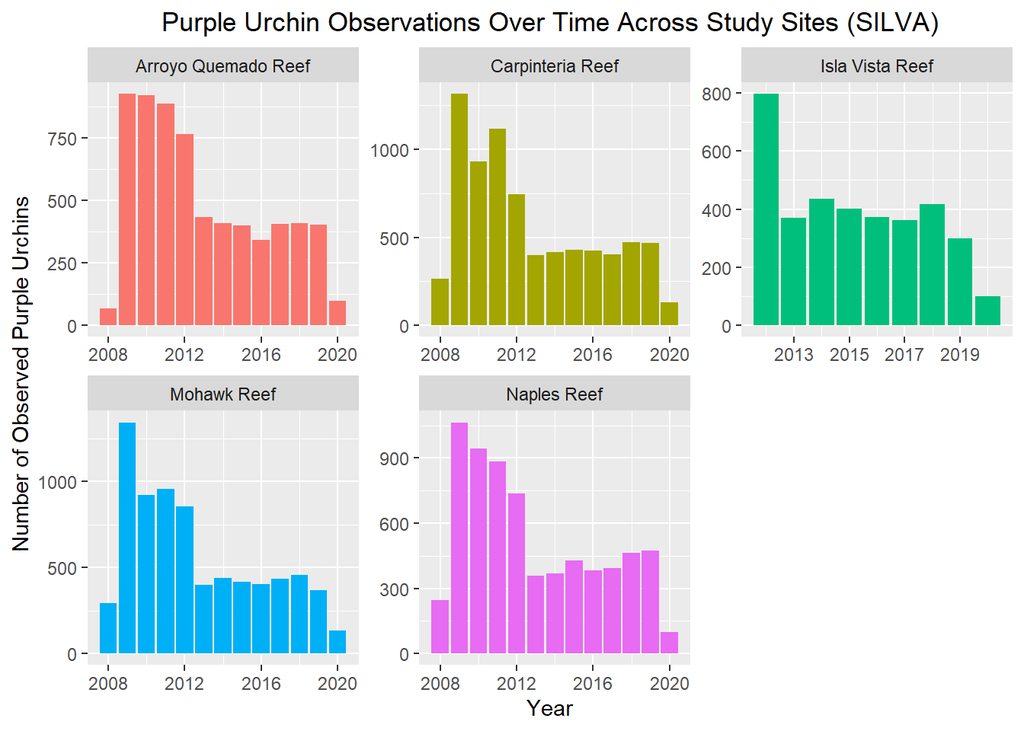

**Figure 2** Bar charts showing the change in Purple Urchins observed at each site from 2008-2020. Overall, urchin populations have seemingly been on the decline since observations started. Note: Isla Vista Reef observations start in 2012 opposed to 2008.

```r
purple_urchins <- urchins %>% # set the data we are working with
  filter(common_name == "Purple Urchin") %>% # filter to obtain only Purple Urchin rows
  mutate(date = mdy(date)) %>% # change the date column to class = Date
  mutate(year = year(date)) %>% # create a year coloumn
  mutate(site_full = case_when( # set a "if_else" like statement to make a column with full site names
    site == "NAPL" ~ "Naples Reef",
    site == "AQUE" ~ "Arroyo Quemado Reef",
    site == "CARP" ~ "Carpinteria Reef",
    site == "MOHK" ~ "Mohawk Reef",
    site == "IVEE" ~ "Isla Vista Reef"))

purple_urchin_sites <- purple_urchins %>% # read in the purple urchin data
  group_by(site_full, year) %>% # group by the two variables we want to use in our analysis (site and year)
  summarise(observed = n()) # makes a table with the total observations by year and site

ggplot(data = purple_urchin_sites, aes(x = year, y = observed)) + # sets what data will be graphed
  geom_bar(aes(fill = site_full), stat = "identity") + # colors plots by site and allows geom_bar to use two aes() variables
  facet_wrap(~ site_full, scales = 'free') + # makes faceted plots by site and allows each to have its own axes.
  labs(x= "Year", # changes name of x axis
       y = "Number of Observed Purple Urchins")+ # changes names of y-axis
  ggtitle("Purple Urchin Observations Over Time Across Study Sites (SILVA)") + # title of graphs
  theme(plot.title = element_text(hjust = 0.5)) + # centers graph
  guides(fill = "none") # removes legend as to not compress the plots
```

Purple Urchin populations seem to be on the decline by looking on the graphs. However, you have to take in account the sampling method, scope, and team behind the data collection before assuming this is representative of true population decline. For example, the scope of the data does not appear to focus on estimating population size like a catch-tag-release-recapture method would (as there is no recapture/initial capture columns). Other explanations for the apparent decline could be fewer people able to go out to sample, cloudy water conditions,or the nature of the experiment being conducted, for example.